# Red Wine Data Analysis

Urmay Shah

Sunday, October 15, 2017

# Table of content

### 1. Introduction

### 2. Exploring Data

### 3. Univariate Analysis

### 4. Bivariate Analysis

### 5. Multivariate Analysis

### 6. Final Plots and Summary

### 7. Reflection

Before analysing the dataset load the below packages first.

### 1. Introduction:

> This project aims to explore the Red wine dataset.The main objective of this project is to identify which chemical properties influence the quality of red wine.During our exploratory analysis,we will try to answer this question and implement Exploratory Data Analysis using R programming languge.we will perform analysis using various plots and other inbuilt R functions.

### 2.Exploring Data:

```
## [1] "H:/udacity_course_file/EDA_Project"
```

```
##  [1] "fixed.acidity"        "volatile.acidity"     "citric.acid"
##  [4] "residual.sugar"       "chlorides"            "free.sulfur.dioxide"
##  [7] "total.sulfur.dioxide" "density"              "pH"
## [10] "sulphates"            "alcohol"              "quality"
```

```
##   fixed.acidity volatile.acidity citric.acid residual.sugar chlorides
## 1           7.4             0.70        0.00            1.9     0.076
## 2           7.8             0.88        0.00            2.6     0.098
## 3           7.8             0.76        0.04            2.3     0.092
## 4          11.2             0.28        0.56            1.9     0.075
## 5           7.4             0.70        0.00            1.9     0.076
##   free.sulfur.dioxide total.sulfur.dioxide density   pH sulphates alcohol
## 1                  11                   34  0.9978 3.51      0.56     9.4
## 2                  25                   67  0.9968 3.20      0.68     9.8
## 3                  15                   54  0.9970 3.26      0.65     9.8
## 4                  17                   60  0.9980 3.16      0.58     9.8
## 5                  11                   34  0.9978 3.51      0.56     9.4
##   quality
## 1       5
## 2       5
## 3       5
## 4       6
## 5       5
```

From the output you can see that there are total 12 variables are there in the dataset. To further explore the dataset will run following command.

```
## 'data.frame':    1599 obs. of  12 variables:
##  $ fixed.acidity       : num  7.4 7.8 7.8 11.2 7.4 7.4 7.9 7.3 7.8 7.5 ...
##  $ volatile.acidity    : num  0.7 0.88 0.76 0.28 0.7 0.66 0.6 0.65 0.58 0.5 ...
##  $ citric.acid         : num  0 0 0.04 0.56 0 0 0.06 0 0.02 0.36 ...
##  $ residual.sugar      : num  1.9 2.6 2.3 1.9 1.9 1.8 1.6 1.2 2 6.1 ...
##  $ chlorides           : num  0.076 0.098 0.092 0.075 0.076 0.075 0.069 0.065 0.073 0.071 ...
##  $ free.sulfur.dioxide : num  11 25 15 17 11 13 15 15 9 17 ...
##  $ total.sulfur.dioxide: num  34 67 54 60 34 40 59 21 18 102 ...
##  $ density             : num  0.998 0.997 0.997 0.998 0.998 ...
##  $ pH                  : num  3.51 3.2 3.26 3.16 3.51 3.51 3.3 3.39 3.36 3.35 ...
##  $ sulphates           : num  0.56 0.68 0.65 0.58 0.56 0.56 0.46 0.47 0.57 0.8 ...
##  $ alcohol             : num  9.4 9.8 9.8 9.8 9.4 9.4 9.4 10 9.5 10.5 ...
##  $ quality             : int  5 5 5 6 5 5 5 7 7 5 ...
```

```
##  fixed.acidity   volatile.acidity  citric.acid    residual.sugar
##  Min.   : 4.60   Min.   :0.1200   Min.   :0.000   Min.   : 0.900
##  1st Qu.: 7.10   1st Qu.:0.3900   1st Qu.:0.090   1st Qu.: 1.900
##  Median : 7.90   Median :0.5200   Median :0.260   Median : 2.200
##  Mean   : 8.32   Mean   :0.5278   Mean   :0.271   Mean   : 2.539
##  3rd Qu.: 9.20   3rd Qu.:0.6400   3rd Qu.:0.420   3rd Qu.: 2.600
##  Max.   :15.90   Max.   :1.5800   Max.   :1.000   Max.   :15.500
##    chlorides       free.sulfur.dioxide total.sulfur.dioxide
##  Min.   :0.01200   Min.   : 1.00       Min.   :  6.00
##  1st Qu.:0.07000   1st Qu.: 7.00       1st Qu.: 22.00
##  Median :0.07900   Median :14.00       Median : 38.00
##  Mean   :0.08747   Mean   :15.87       Mean   : 46.47
##  3rd Qu.:0.09000   3rd Qu.:21.00       3rd Qu.: 62.00
##  Max.   :0.61100   Max.   :72.00       Max.   :289.00
##     density             pH          sulphates         alcohol
##  Min.   :0.9901   Min.   :2.740   Min.   :0.3300   Min.   : 8.40
##  1st Qu.:0.9956   1st Qu.:3.210   1st Qu.:0.5500   1st Qu.: 9.50
##  Median :0.9968   Median :3.310   Median :0.6200   Median :10.20
##  Mean   :0.9967   Mean   :3.311   Mean   :0.6581   Mean   :10.42
##  3rd Qu.:0.9978   3rd Qu.:3.400   3rd Qu.:0.7300   3rd Qu.:11.10
##  Max.   :1.0037   Max.   :4.010   Max.   :2.0000   Max.   :14.90
##     quality
##  Min.   :3.000
##  1st Qu.:5.000
##  Median :6.000
##  Mean   :5.636
##  3rd Qu.:6.000
##  Max.   :8.000
```

```
##
##   3   4   5   6   7   8
##  10  53 681 638 199  18
```

From above table you can see that quality results are between 3 to 8.and most of the values are for 5 and 6 quality.

Now as we are interested in red wine quality so will first find the correlation of wine quality with other variable. As data analyst we can not afford exploring the all the 12 variable.

```
##                      fixed.acidity volatile.acidity citric.acid
## fixed.acidity                 1.00            -0.26        0.67
## volatile.acidity             -0.26             1.00       -0.55
## citric.acid                   0.67            -0.55        1.00
## residual.sugar                0.11             0.00        0.14
## chlorides                     0.09             0.06        0.20
## free.sulfur.dioxide          -0.15            -0.01       -0.06
## total.sulfur.dioxide         -0.11             0.08        0.04
## density                       0.67             0.02        0.36
## pH                           -0.68             0.23       -0.54
## sulphates                     0.18            -0.26        0.31
## alcohol                      -0.06            -0.20        0.11
## quality                       0.12            -0.39        0.23
##                      residual.sugar chlorides free.sulfur.dioxide
## fixed.acidity                  0.11      0.09               -0.15
## volatile.acidity               0.00      0.06               -0.01
## citric.acid                    0.14      0.20               -0.06
## residual.sugar                 1.00      0.06                0.19
## chlorides                      0.06      1.00                0.01
## free.sulfur.dioxide            0.19      0.01                1.00
## total.sulfur.dioxide           0.20      0.05                0.67
## density                        0.36      0.20               -0.02
## pH                            -0.09     -0.27                0.07
## sulphates                      0.01      0.37                0.05
## alcohol                        0.04     -0.22               -0.07
## quality                        0.01     -0.13               -0.05
##                      total.sulfur.dioxide density    pH sulphates alcohol
## fixed.acidity                       -0.11    0.67 -0.68      0.18   -0.06
## volatile.acidity                     0.08    0.02  0.23     -0.26   -0.20
## citric.acid                          0.04    0.36 -0.54      0.31    0.11
## residual.sugar                       0.20    0.36 -0.09      0.01    0.04
## chlorides                            0.05    0.20 -0.27      0.37   -0.22
## free.sulfur.dioxide                  0.67   -0.02  0.07      0.05   -0.07
## total.sulfur.dioxide                 1.00    0.07 -0.07      0.04   -0.21
## density                              0.07    1.00 -0.34      0.15   -0.50
## pH                                  -0.07   -0.34  1.00     -0.20    0.21
## sulphates                            0.04    0.15 -0.20      1.00    0.09
## alcohol                             -0.21   -0.50  0.21      0.09    1.00
## quality                             -0.19   -0.17 -0.06      0.25    0.48
##                      quality
## fixed.acidity           0.12
## volatile.acidity       -0.39
## citric.acid             0.23
## residual.sugar          0.01
## chlorides              -0.13
## free.sulfur.dioxide    -0.05
## total.sulfur.dioxide   -0.19
## density                -0.17
## pH                     -0.06
## sulphates               0.25
## alcohol                 0.48
## quality                 1.00
```

- so basically we are interested in correlation of other parameters with the quality parameter which are:
1. Fixed Acidity: 0.12
2. volatile Acidity: -0.39
3. citric.acid: 0.23
4. residual.sugar:0.01
5. chlorides:-0.13
6. free.sulfur.dioxide:-0.05
7. total.sulfur.dioxide:-0.19
8. density:-0.17
9. pH: -0.06
10. sulphates:0.25
11. alcohol:0.48

For Ploting them we can use below funnction which comes with GGally library

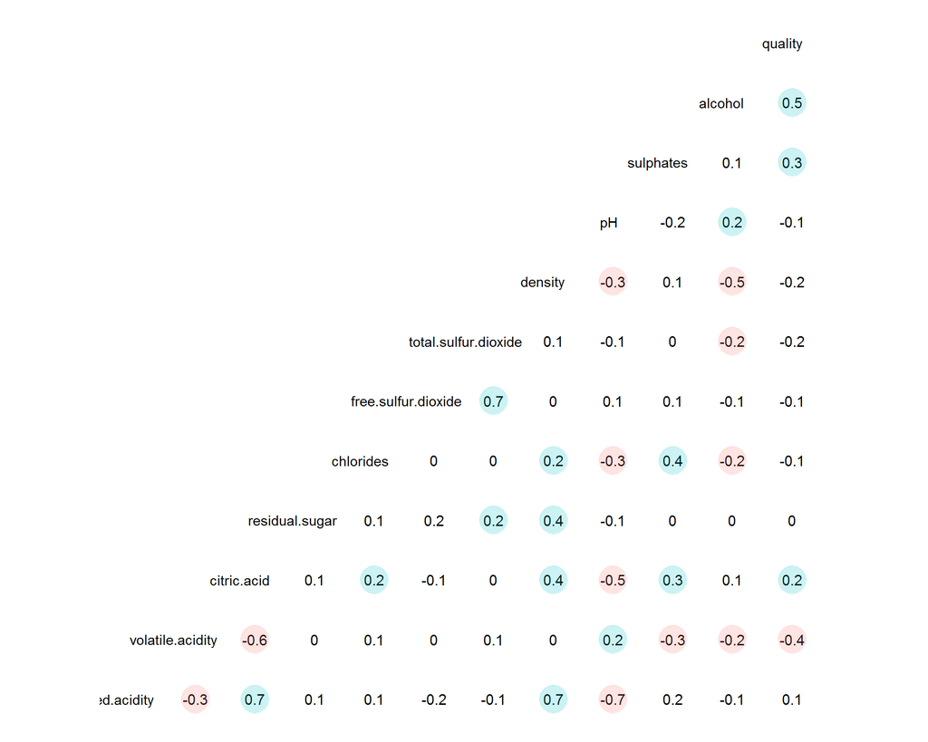

- It is said that the correlation greter that +-(3) is considerable But in this analysis we will consider the correlation > +- (0.23).We will only perform analysis on the parameters which have >+- (0.23) correlation with wine quality.
- so we will explore the values of volatile acidity,citric acid,sulphate,alcohol for better wine quality.

### 3.Univariate Analysis:

> In this section we will explore individual parameter.Our exploration will mainly focused on more correlated parameter,but few time we will also explore one or two other less correlated parameters just to check that we are not missing something.

Below we have given little description about the parameters used in the dataset.

1. volatile.acidity: At the high level it can lead to an unpleasent ,vinager taste
2. citric.acid: Adds freshness and Flavours to wines
3. alcohol: % of alcohol content
4. sulphates: a wine additive which can contribute to sulfur dioxide gas (S02) levels, which acts as an antimicrobial and antioxidant

#### 3.1 Citric Acid

```
##    Min. 1st Qu.  Median    Mean 3rd Qu.    Max.
##   0.000   0.090   0.260   0.271   0.420   1.000
```

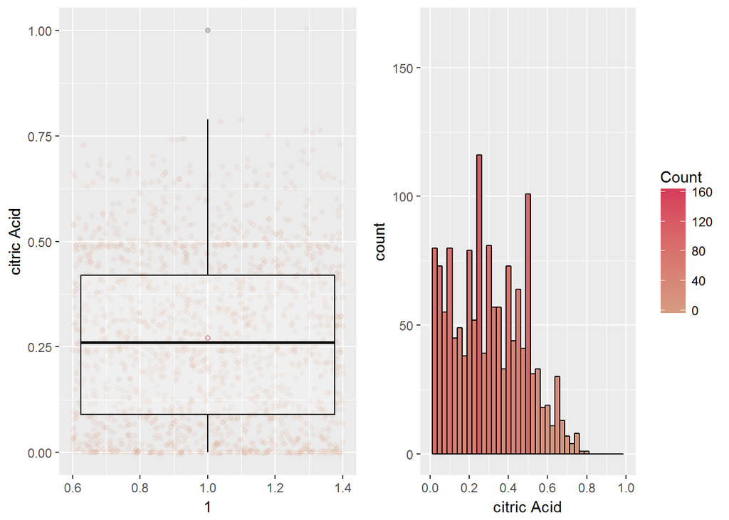

The distribution of the citric acid seems rectangular.and most of values have almost same counts.You can also notice it from the difference between mean and median value.

#### 3.2 Sulphates

```
##    Min. 1st Qu.  Median    Mean 3rd Qu.    Max.
##  0.3300  0.5500  0.6200  0.6581  0.7300  2.0000
```

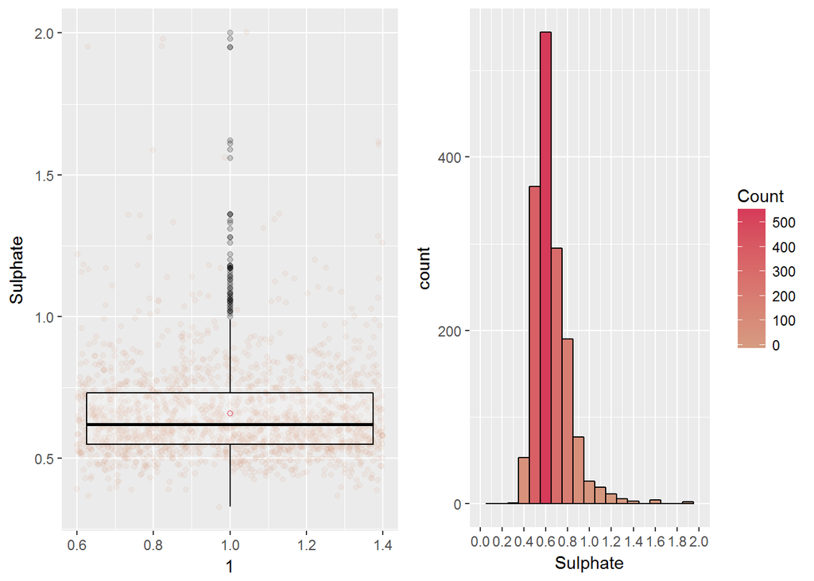

#### 3.3 Volatile Acidity

```
##    Min. 1st Qu.  Median    Mean 3rd Qu.    Max.
##  0.1200  0.3900  0.5200  0.5278  0.6400  1.5800
```

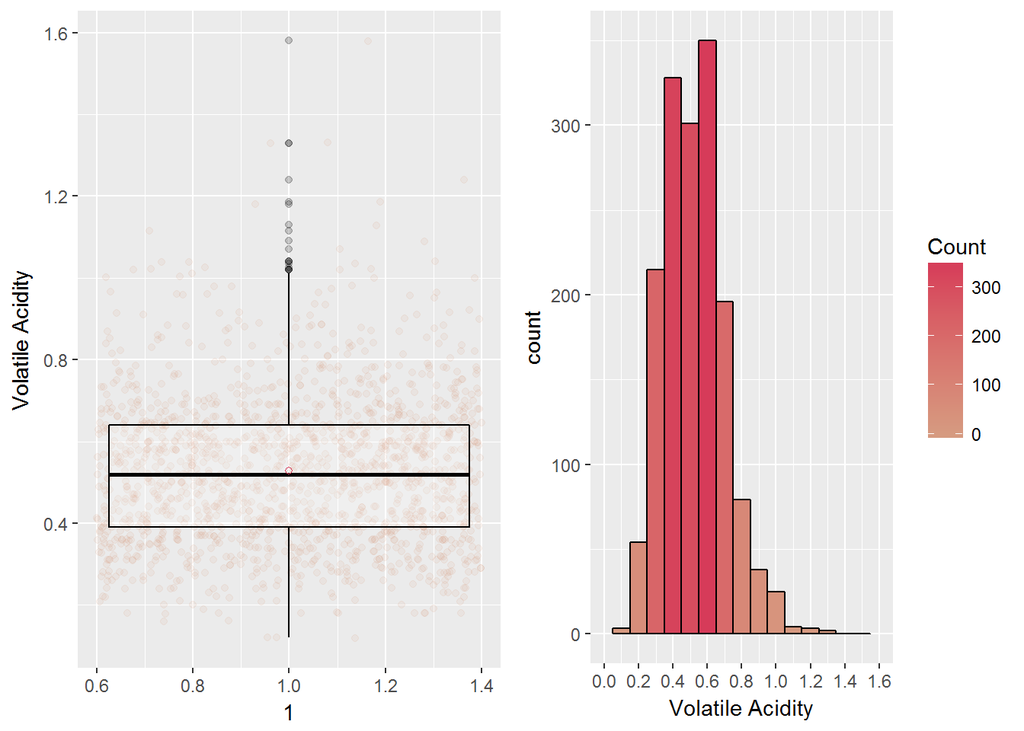

The distribution of volatile acidity seems bimodal.From the figure we can notice the two peaks at 0.4 and 0.6.

#### 3.4 Alcohol

```
##    Min. 1st Qu.  Median    Mean 3rd Qu.    Max.
##    8.40    9.50   10.20   10.42   11.10   14.90
```

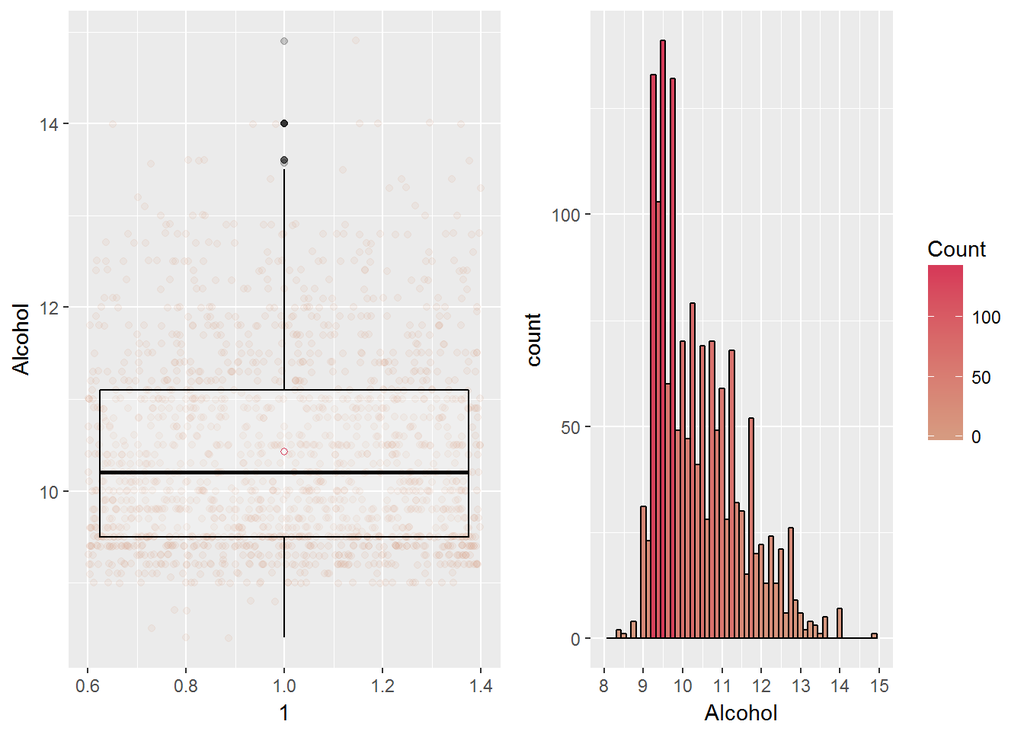

Alcohol seems to have positively skewed distribution with less no of outliers.

#### 3.5 Total Sulfur Dioxide

```
##    Min. 1st Qu.  Median    Mean 3rd Qu.    Max.
##    6.00   22.00   38.00   46.47   62.00  289.00
```

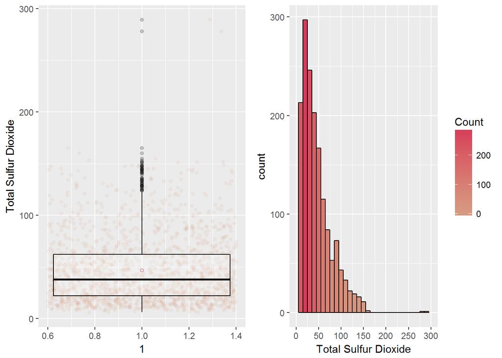

Total Sulpher Dioxide is also positively skewed with long tail.Having few outliers which are visible from the plot.Clearly visible from mean and median value difference.

#### 3.7 Exploring the wine quality & wine quality category

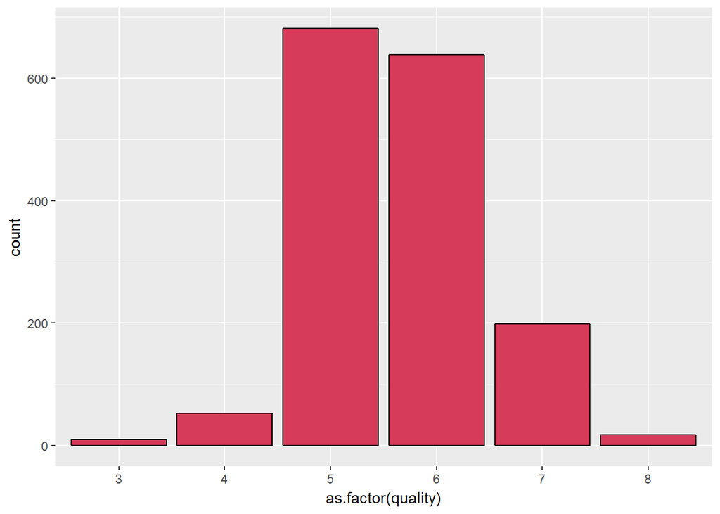

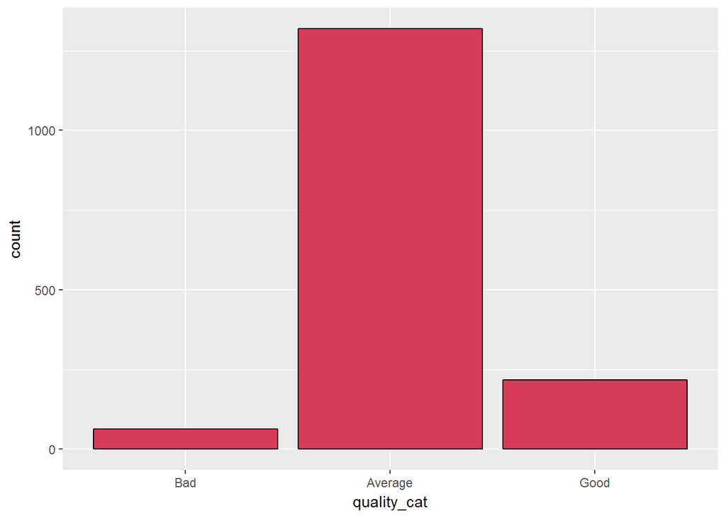

```
##
##   3   4   5   6   7   8
##  10  53 681 638 199  18
```

```
##
##     Bad Average    Good
##      63    1319     217
```

From above graph we can see that we have most of wines with average quality.our aim is to identify variables which affect the quality of wine.

## 4. Bivariate Analysis:

> In this section we will analyze the two variables together.As we are interested in wine quality variable we will first analayze it with most correlated parameter using statestics and later with the visualization.

#### 4.1 Bivariate Analysis with Statestics.

```
## wine_data$quality: 3
##    Min. 1st Qu.  Median    Mean 3rd Qu.    Max.
##   8.400   9.725   9.925   9.955  10.580  11.000
## --------------------------------------------------------
## wine_data$quality: 4
##    Min. 1st Qu.  Median    Mean 3rd Qu.    Max.
##    9.00    9.60   10.00   10.27   11.00   13.10
## --------------------------------------------------------
## wine_data$quality: 5
##    Min. 1st Qu.  Median    Mean 3rd Qu.    Max.
##     8.5     9.4     9.7     9.9    10.2    14.9
## --------------------------------------------------------
## wine_data$quality: 6
##    Min. 1st Qu.  Median    Mean 3rd Qu.    Max.
##    8.40    9.80   10.50   10.63   11.30   14.00
## --------------------------------------------------------
## wine_data$quality: 7
##    Min. 1st Qu.  Median    Mean 3rd Qu.    Max.
##    9.20   10.80   11.50   11.47   12.10   14.00
## --------------------------------------------------------
## wine_data$quality: 8
##    Min. 1st Qu.  Median    Mean 3rd Qu.    Max.
##    9.80   11.32   12.15   12.09   12.88   14.00
```

```
## wine_data$quality_cat: Bad
##    Min. 1st Qu.  Median    Mean 3rd Qu.    Max.
##    8.40    9.60   10.00   10.22   11.00   13.10
## --------------------------------------------------------
## wine_data$quality_cat: Average
##    Min. 1st Qu.  Median    Mean 3rd Qu.    Max.
##    8.40    9.50   10.00   10.25   10.90   14.90
## --------------------------------------------------------
## wine_data$quality_cat: Good
##    Min. 1st Qu.  Median    Mean 3rd Qu.    Max.
##    9.20   10.80   11.60   11.52   12.20   14.00
```

```
## wine_data$quality: 3
##    Min. 1st Qu.  Median    Mean 3rd Qu.    Max.
##  0.0000  0.0050  0.0350  0.1710  0.3275  0.6600
## --------------------------------------------------------
## wine_data$quality: 4
##    Min. 1st Qu.  Median    Mean 3rd Qu.    Max.
##  0.0000  0.0300  0.0900  0.1742  0.2700  1.0000
## --------------------------------------------------------
## wine_data$quality: 5
##    Min. 1st Qu.  Median    Mean 3rd Qu.    Max.
##  0.0000  0.0900  0.2300  0.2437  0.3600  0.7900
## --------------------------------------------------------
## wine_data$quality: 6
##    Min. 1st Qu.  Median    Mean 3rd Qu.    Max.
##  0.0000  0.0900  0.2600  0.2738  0.4300  0.7800
## --------------------------------------------------------
## wine_data$quality: 7
##    Min. 1st Qu.  Median    Mean 3rd Qu.    Max.
##  0.0000  0.3050  0.4000  0.3752  0.4900  0.7600
## --------------------------------------------------------
## wine_data$quality: 8
##    Min. 1st Qu.  Median    Mean 3rd Qu.    Max.
##  0.0300  0.3025  0.4200  0.3911  0.5300  0.7200
```

```
## wine_data$quality_cat: Bad
##    Min. 1st Qu.  Median    Mean 3rd Qu.    Max.
##  0.0000  0.0200  0.0800  0.1737  0.2700  1.0000
## --------------------------------------------------------
## wine_data$quality_cat: Average
##    Min. 1st Qu.  Median    Mean 3rd Qu.    Max.
##  0.0000  0.0900  0.2400  0.2583  0.4000  0.7900
## --------------------------------------------------------
## wine_data$quality_cat: Good
##    Min. 1st Qu.  Median    Mean 3rd Qu.    Max.
##  0.0000  0.3000  0.4000  0.3765  0.4900  0.7600
```

- Note that more the citric acid good the wine is but still for clear asumption will go with category evaluation.And from the category evaluation we can see this in detail.

```
## wine_data$quality: 3
##    Min. 1st Qu.  Median    Mean 3rd Qu.    Max.
##  0.4400  0.6475  0.8450  0.8845  1.0100  1.5800
## --------------------------------------------------------
## wine_data$quality: 4
##    Min. 1st Qu.  Median    Mean 3rd Qu.    Max.
##   0.230   0.530   0.670   0.694   0.870   1.130
## --------------------------------------------------------
## wine_data$quality: 5
##    Min. 1st Qu.  Median    Mean 3rd Qu.    Max.
##   0.180   0.460   0.580   0.577   0.670   1.330
## --------------------------------------------------------
## wine_data$quality: 6
##    Min. 1st Qu.  Median    Mean 3rd Qu.    Max.
##  0.1600  0.3800  0.4900  0.4975  0.6000  1.0400
## --------------------------------------------------------
## wine_data$quality: 7
##    Min. 1st Qu.  Median    Mean 3rd Qu.    Max.
##  0.1200  0.3000  0.3700  0.4039  0.4850  0.9150
## --------------------------------------------------------
## wine_data$quality: 8
##    Min. 1st Qu.  Median    Mean 3rd Qu.    Max.
##  0.2600  0.3350  0.3700  0.4233  0.4725  0.8500
```

```
## wine_data$quality_cat: Bad
##    Min. 1st Qu.  Median    Mean 3rd Qu.    Max.
##  0.2300  0.5650  0.6800  0.7242  0.8825  1.5800
## --------------------------------------------------------
## wine_data$quality_cat: Average
##    Min. 1st Qu.  Median    Mean 3rd Qu.    Max.
##  0.1600  0.4100  0.5400  0.5386  0.6400  1.3300
## --------------------------------------------------------
## wine_data$quality_cat: Good
##    Min. 1st Qu.  Median    Mean 3rd Qu.    Max.
##  0.1200  0.3000  0.3700  0.4055  0.4900  0.9150
```

- More the accidity bad the wine is!

```
## wine_data$quality: 3
##    Min. 1st Qu.  Median    Mean 3rd Qu.    Max.
##  0.4000  0.5125  0.5450  0.5700  0.6150  0.8600
## --------------------------------------------------------
## wine_data$quality: 4
##    Min. 1st Qu.  Median    Mean 3rd Qu.    Max.
##  0.3300  0.4900  0.5600  0.5964  0.6000  2.0000
## --------------------------------------------------------
## wine_data$quality: 5
##    Min. 1st Qu.  Median    Mean 3rd Qu.    Max.
##   0.370   0.530   0.580   0.621   0.660   1.980
## --------------------------------------------------------
## wine_data$quality: 6
##    Min. 1st Qu.  Median    Mean 3rd Qu.    Max.
##  0.4000  0.5800  0.6400  0.6753  0.7500  1.9500
## --------------------------------------------------------
## wine_data$quality: 7
##    Min. 1st Qu.  Median    Mean 3rd Qu.    Max.
##  0.3900  0.6500  0.7400  0.7413  0.8300  1.3600
## --------------------------------------------------------
## wine_data$quality: 8
##    Min. 1st Qu.  Median    Mean 3rd Qu.    Max.
##  0.6300  0.6900  0.7400  0.7678  0.8200  1.1000
```

```
## wine_data$quality_cat: Bad
##    Min. 1st Qu.  Median    Mean 3rd Qu.    Max.
##  0.3300  0.4950  0.5600  0.5922  0.6000  2.0000
## --------------------------------------------------------
## wine_data$quality_cat: Average
##    Min. 1st Qu.  Median    Mean 3rd Qu.    Max.
##  0.3700  0.5400  0.6100  0.6473  0.7000  1.9800
## --------------------------------------------------------
## wine_data$quality_cat: Good
##    Min. 1st Qu.  Median    Mean 3rd Qu.    Max.
##  0.3900  0.6500  0.7400  0.7435  0.8200  1.3600
```

- More the sulphate good the wine is!

Adding another variable for the acidity additaion

```
## wine_data$quality: 3
##    Min. 1st Qu.  Median    Mean 3rd Qu.    Max.
##   7.460   8.051   8.882   9.244  10.460  12.180
## --------------------------------------------------------
## wine_data$quality: 4
##    Min. 1st Qu.  Median    Mean 3rd Qu.    Max.
##   5.120   7.380   8.185   8.473   9.070  12.960
## --------------------------------------------------------
## wine_data$quality: 5
##    Min. 1st Qu.  Median    Mean 3rd Qu.    Max.
##   5.520   7.735   8.390   8.744   9.490  16.260
## --------------------------------------------------------
## wine_data$quality: 6
##    Min. 1st Qu.  Median    Mean 3rd Qu.    Max.
##   5.300   7.605   8.400   8.845   9.881  14.610
## --------------------------------------------------------
## wine_data$quality: 7
##    Min. 1st Qu.  Median    Mean 3rd Qu.    Max.
##   5.320   7.880   9.110   9.276  10.480  16.280
## --------------------------------------------------------
## wine_data$quality: 8
##    Min. 1st Qu.  Median    Mean 3rd Qu.    Max.
##   5.420   7.625   8.730   8.990  10.530  12.910
```

```
## wine_data$quality_cat: Bad
##    Min. 1st Qu.  Median    Mean 3rd Qu.    Max.
##   5.120   7.525   8.280   8.596   9.163  12.960
## --------------------------------------------------------
## wine_data$quality_cat: Average
##    Min. 1st Qu.  Median    Mean 3rd Qu.    Max.
##   5.300   7.665   8.390   8.793   9.635  16.260
## --------------------------------------------------------
## wine_data$quality_cat: Good
##    Min. 1st Qu.  Median    Mean 3rd Qu.    Max.
##   5.320   7.780   9.040   9.253  10.490  16.280
```

- Not getting much insights from direct rating analysis.
- From second analysis with quality category vs total acidity you can see the difference between Good and (average & bad together).

#### 4.2 Bivariate Analysis with different plots.

- Now we want to analyze all the variable with quality categorization inorder to check that going with categorization and only 4 more correlated paramater is right or we are missing something.And how our newly added parmeter total acidity behaves with this.

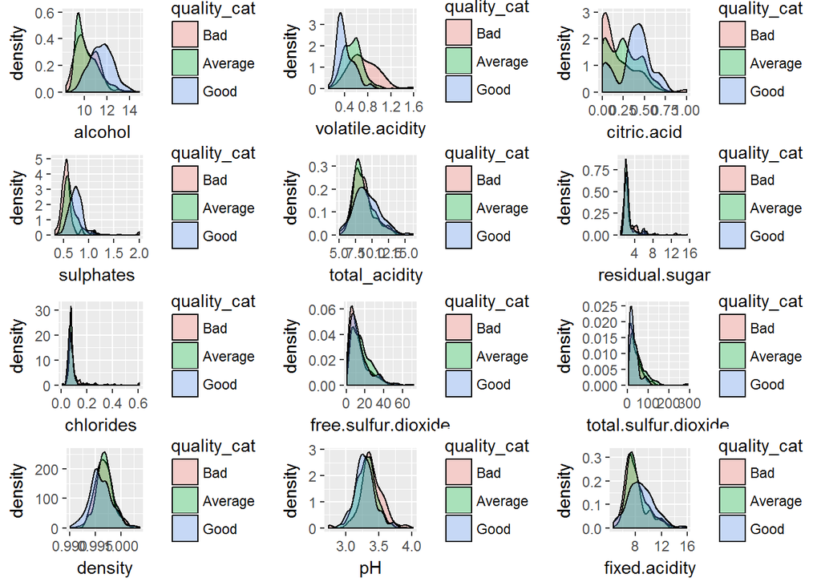

- see the first four plot of the graph.we can clearly see the difference in density for every category in first four plots.Even our newly defined variable “total acidity” is not able to identify the difference clearly.And all other variables seems overlaping to eachother for all category.
- Now alayzing individual parameter with Red wine quality parameter.

##### 1. Alcohol

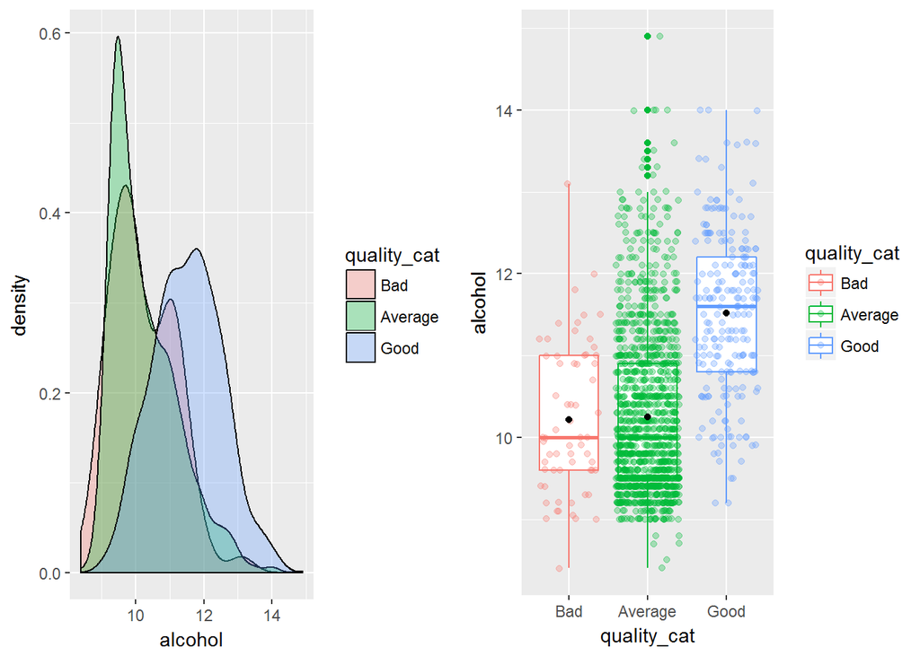

- Good quality of wine have higher alcohol value.

##### 2. Sulphate

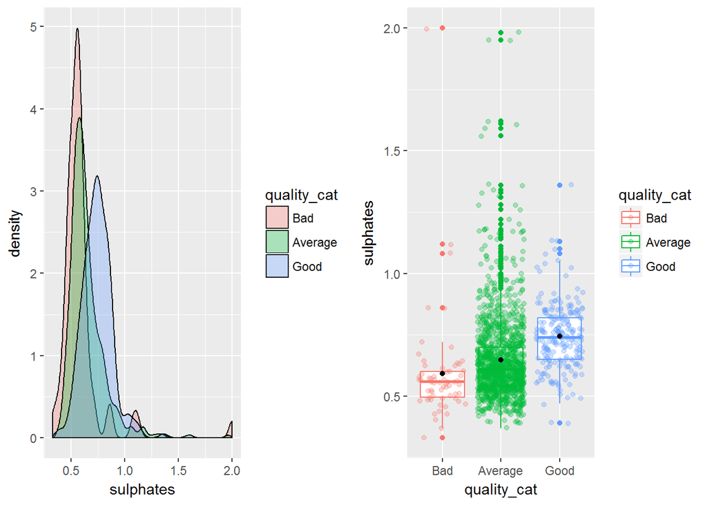

- Higher quality of wine have higher sulphates.

##### 3. Volatile Acidity

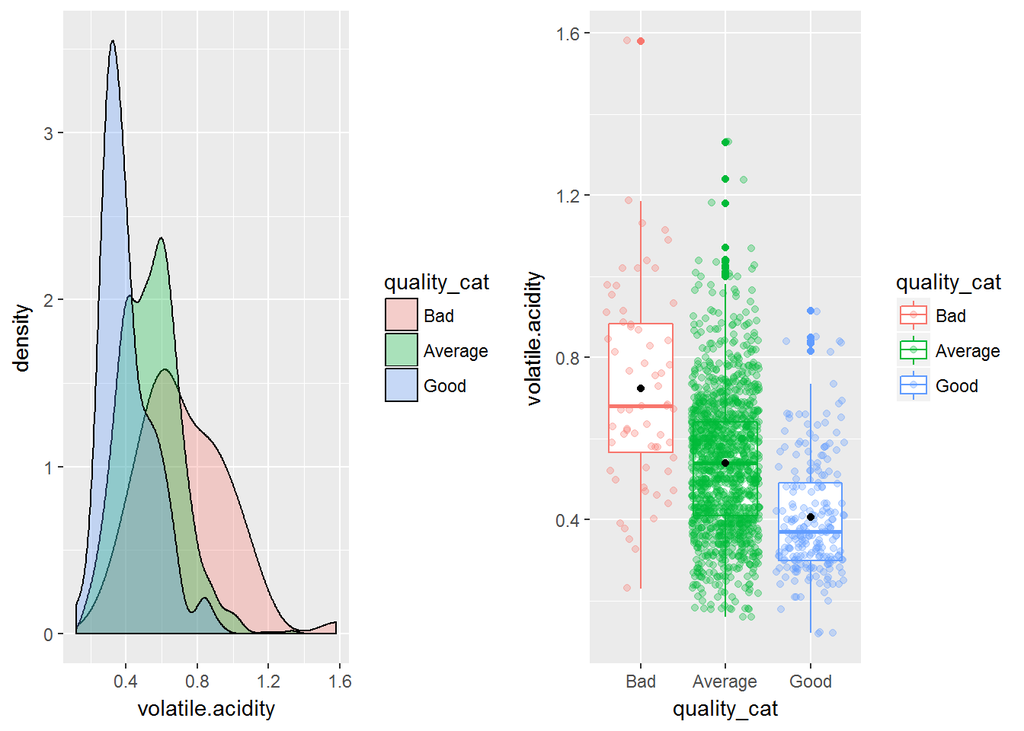

- Higher quality of wine have lower volatile acidity

##### 4. Citric Acid

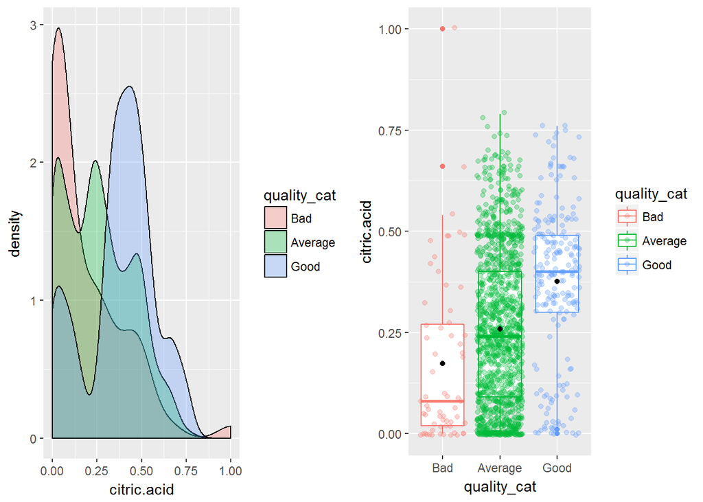

- Higher quality of wine have higher citric acid
- In previous section we have analyzed the parameters with the wine quality Category.In this section we will analyze the parameters with the wine quality rating.
- the objective behind this analysis is to see that how the values of the parameter varies with Wine quality ratings.

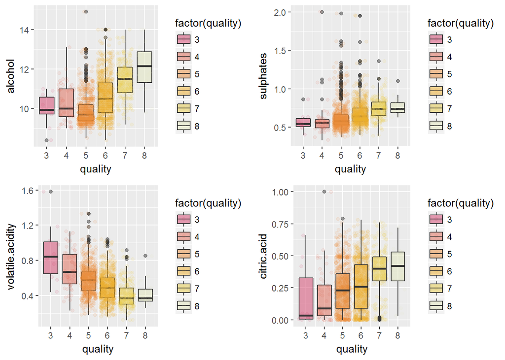

## 5.Multivariate Analysis

> In this section we will analyze multiple variables together.As from above analysis we have identified 4 important parameters in this section we will try to use combination of them with wine category.And will check out which two fits the best.

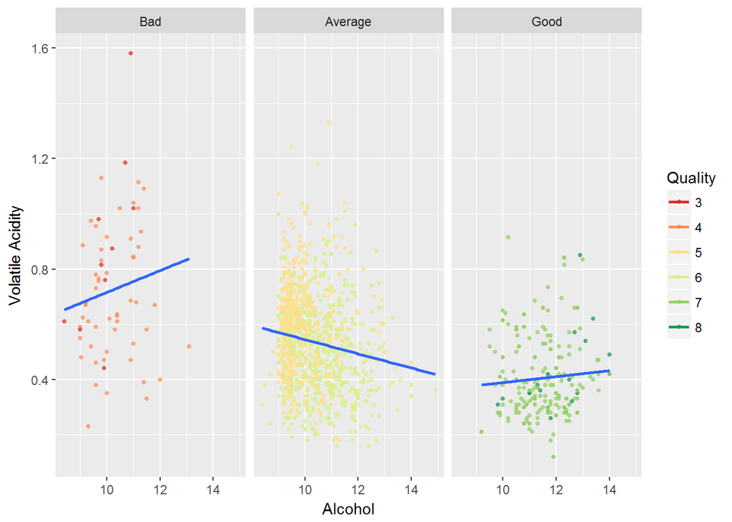

- We can clearly identify the difference with this two parameter combination.Low volatile acidity and more alcohol for the higher quality of wine.For the good quality

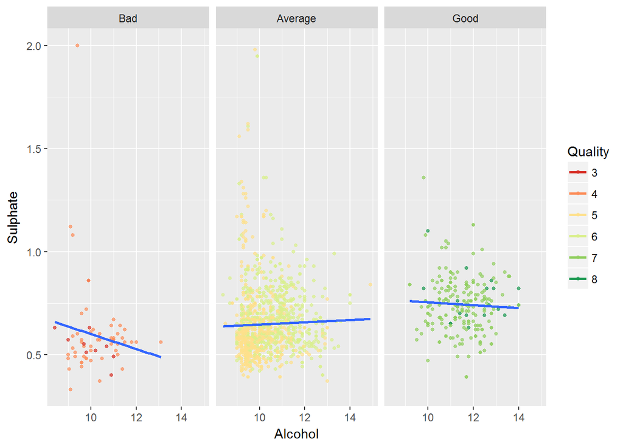

- As you can see from the graph the there is no significant differnce can be found .there are very less no of values for bad and good wine compare to regular wines.But from the plot we can say that higher the value of sulphates with higher value of alcohol gives you good wine as you can see in bad wine plot alcohol value is very limited to 12 but in average wine plot is scattered.

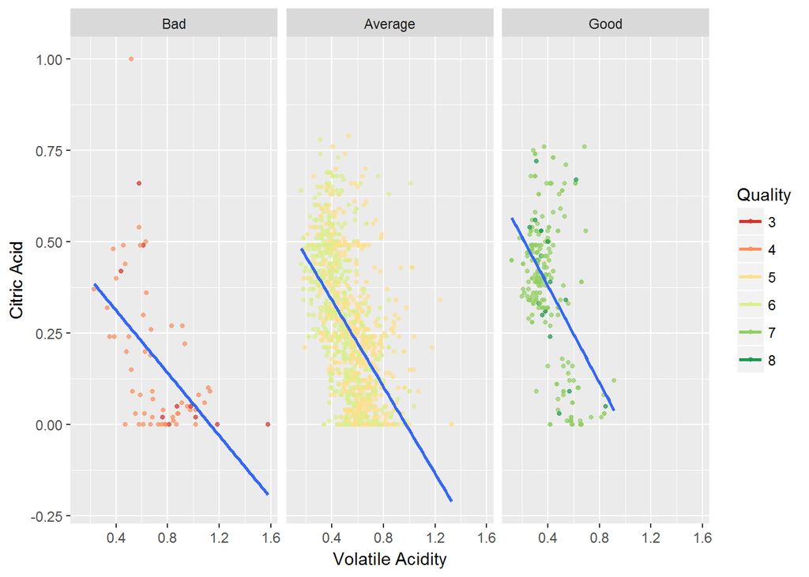

- From this plot we are not abled to get any clear insights.As you can see simillar pattern in all three categories.

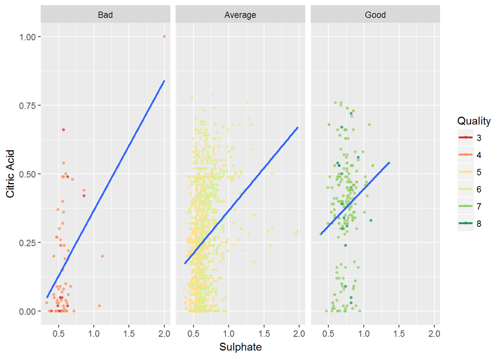

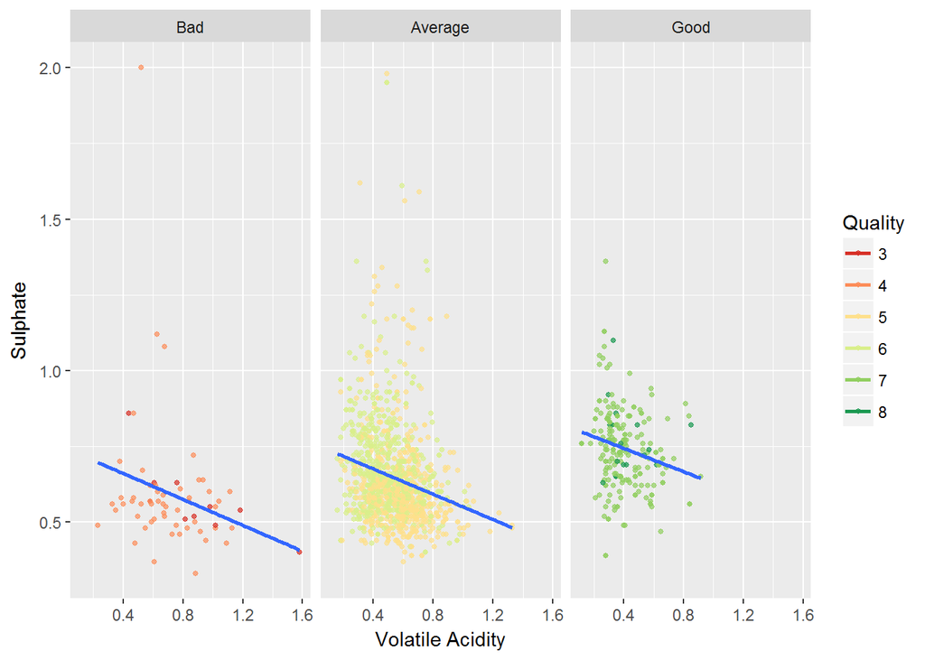

- From the graph we can say for the bad wine sulphate values are less and volatile acidity values are spread.where in the case of regular quality of wine volatile acidity value is between low to medium and in sulphate value is between medium to high.where medium value of sulphate and lower value of volatile acidity gives you good wine quality.

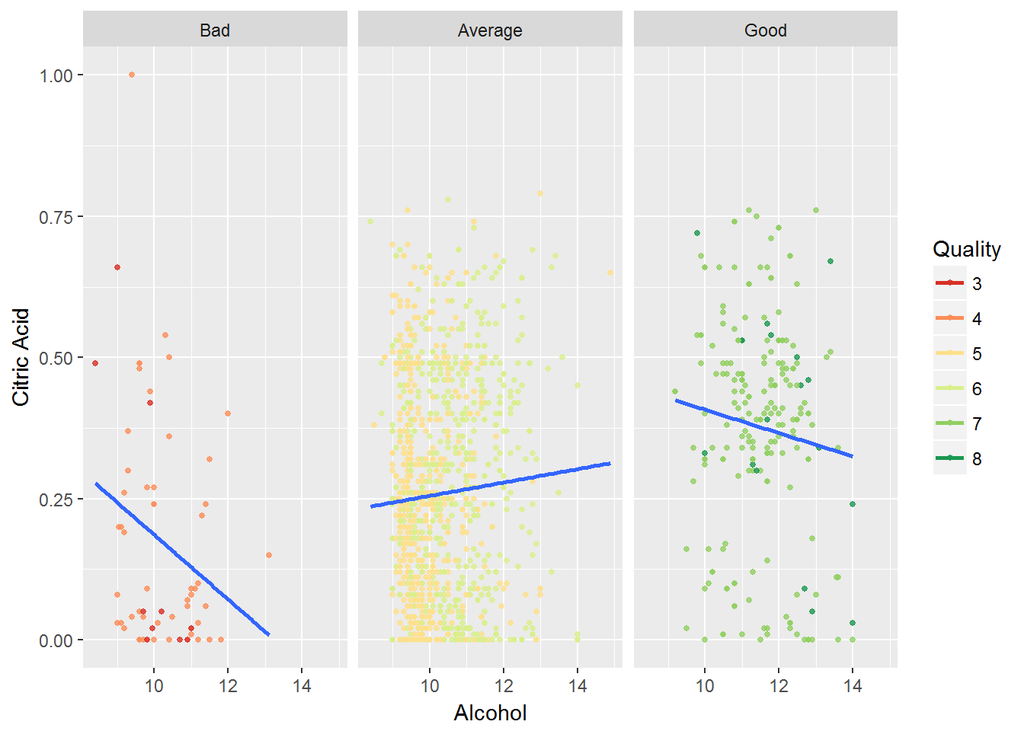

- The plot are very widely spread in regular and good winecategories.in bad quality of wine citric acid and alcohol are very low compare to regular and good wine.Ingoring the widely spread regular wine values we can see clear cluster for good and bad wines.

Detail Analyzing the Citric Acid VS Alcohol.

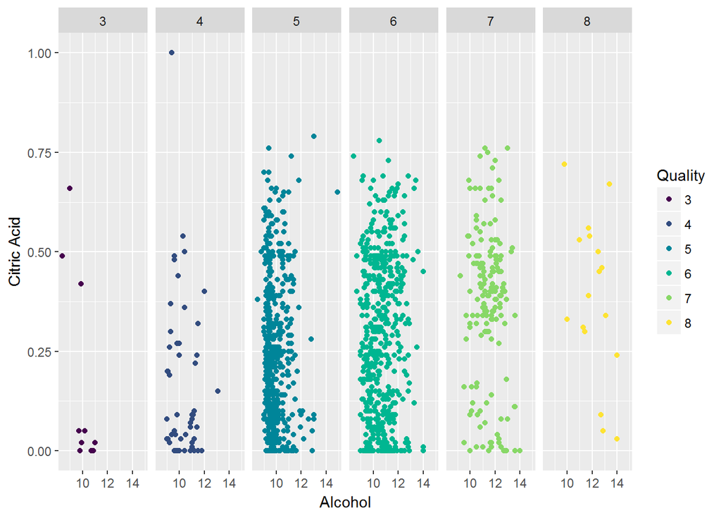

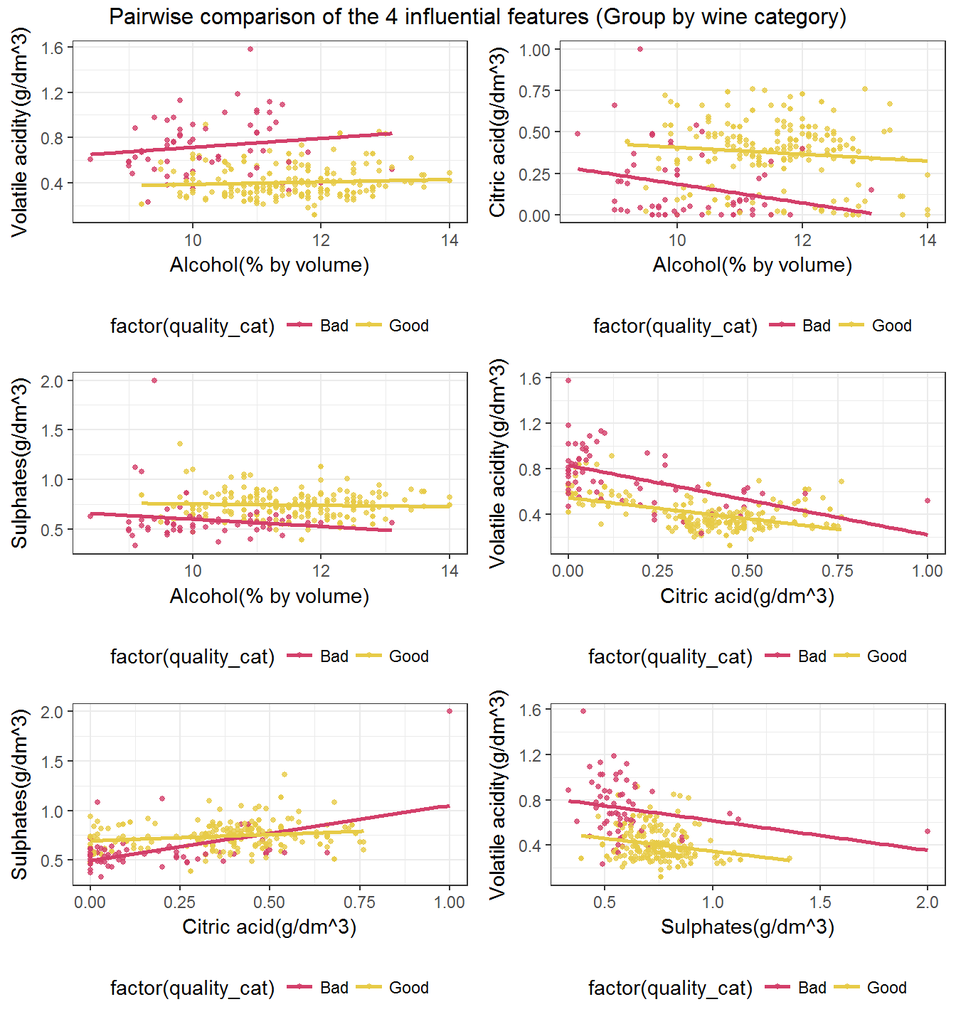

- Obsevation From above plot
  - Volatile Acidity vs Citric Acid:
    1. Good wines :low volatile acidity and medium citric Acid.
    2. Bad wines : medium volatile acidity and medium to low Citric Acid.
  - Volatile Acidity vs Alcohol:
    1. Good Wines :High alcohol and low volatile acidity
    2. Bad Wines :Low alcohol and medium to high volatile acidity
  - Citric Acid vs Alcohol:Clear difference can be found from the graph.
    1. Good Wines:Medium citric acid and high alcohol.
    2. Bad Wines: Low to medium citric acid and low alcohol.
  - Sulphate vs Alcohol:
    1. Good Wines:High alcohol and medium sulphate.
    2. Bad Wines: low sulphate and low to medium alcohol.
  - Volatile Acidity vs Sulphate:
    1. Good Wines:Medium tO high sulphate and low volatile acidity.
    2. Bad Wines: Medium sulphate and medium to high volatile acidity.
  - Sulphate vs Citric Acid:
    1. Good Wines:low to medium sulphate and medium to high citric acid.
    2. Bad Wines:low sulphate low to medium citric acid.

## 6. Final Plots and Summary:

#### 6.1 Plot 1:

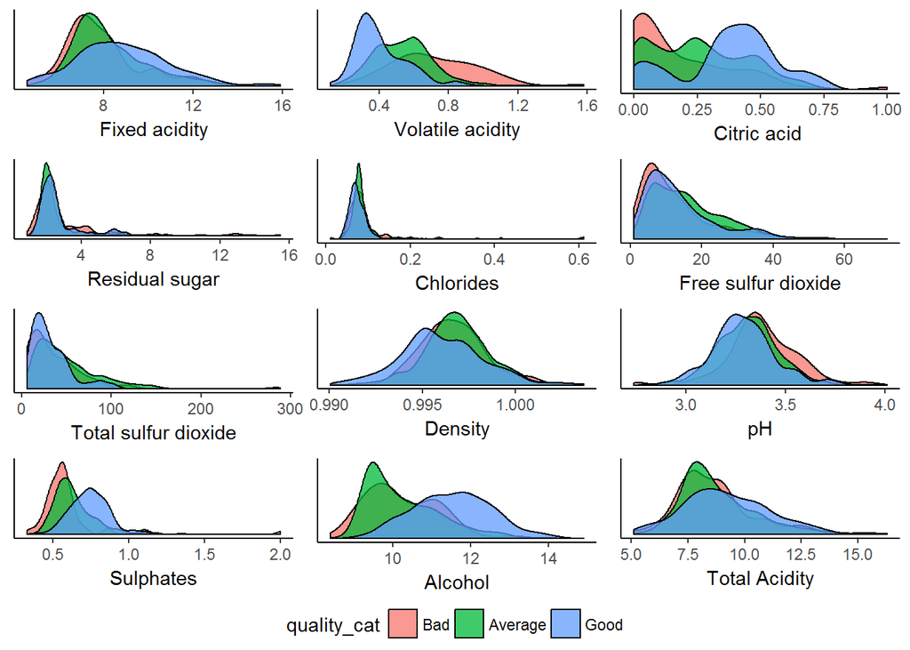

#### Description of Plot 1:

As mentioned earlier we can see categorywise difference involtile acidity,citric acidity,sulphate,alcohol plot.Our new added variable also fails like others variable to have clear category difference.The upper plot shows the density distribution of all parameter for three category.Rest of parameters have overlaping plot for the each category.By this plot we compare all density plot together.

#### 6.2 Plot 2:

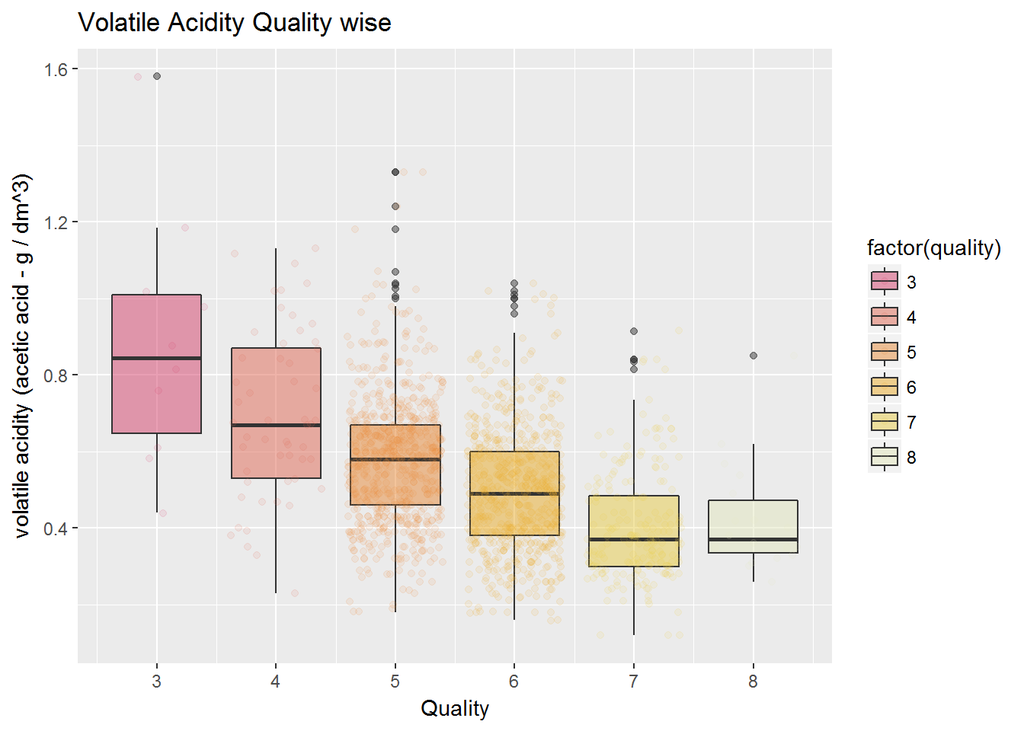

#### 6.3 Plot 3:

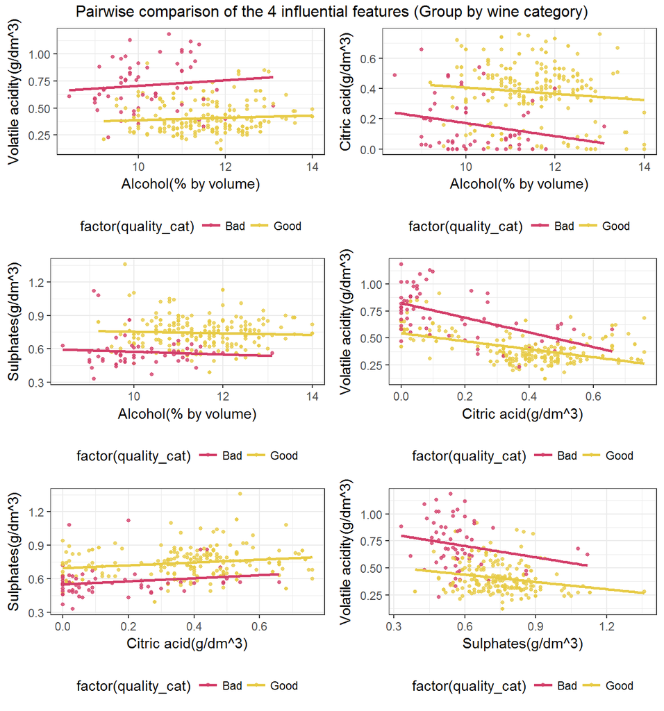

#### Description of Plot 3:

In this plot we have tried combination of four main parameters.We have used scatter plot for the analysis and we have also restricted few parameters value.As the regular wine data is widely spread in this plot we have only analyzed about good and bad wine.